# Point Clustering

Applied Machine Learning in Economics

This data for this workshop is based around **customer segmentation**. The name of the game is to identify groups to focus marketing efforts. Load `tidyverse` and the data `Mall_Customer.csv`. The variable names are annoying, so here you go: `names(customer) = c('id', 'gender', 'age', 'income', 'spending_score')`.

We have historically created indicator variables for female, so in one line `mutate()` a indicator variable `male` and `select()` minus the gender variable. Create a correlation distance (note we do not need to standardize the features).

Fit a hierarchical clustering with an average linkage and plot the dendrogram. Using `cutree()`, trim to just two clusters. Attach a variable `cluster` to the original data that is a `as.factor()` of the labels.

Using `ggplot` with `color = cluster, shape = cluster` in the aesthetics, plot

1. `geom_point()` - income vs spending score
2. `geom_point()` - age vs spending score
3. `geom_jitter()` - male vs spending score

Referring back to the dendrogram, what is the largest realistic number of clusters we can choose? Using this number of clusters, reproduce the three plots

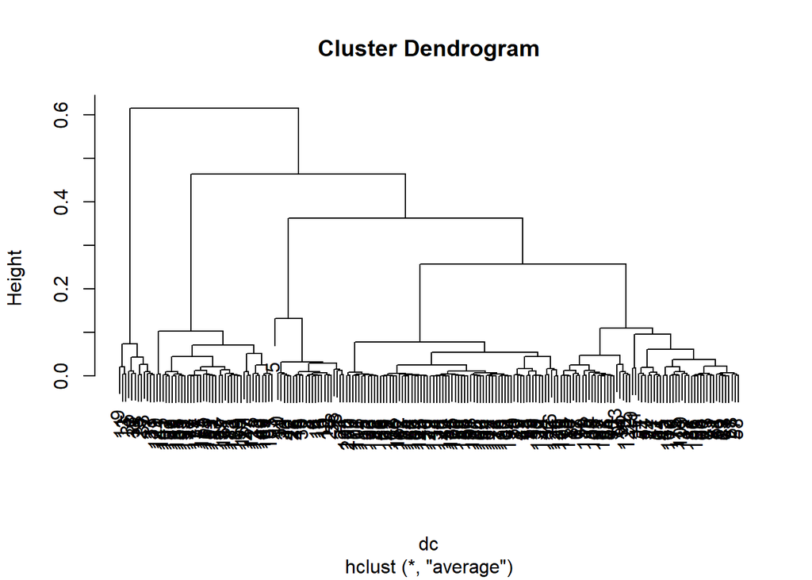

```r
library(tidyverse)
customer = read.csv('C:/Users/johnj/Documents/Data/Applied ML ECON490/workshop data/Mall_Customers.csv')
names(customer) = c('id', 'gender', 'age', 'income', 'spending_score')

customer = customer %>%
  mutate(male = (gender == 'Male')*1) %>%
  select(-gender)

dc = as.dist(1 - cor(t(customer[, -1])))

fit = hclust(dc, method = 'average')
plot(fit)
```

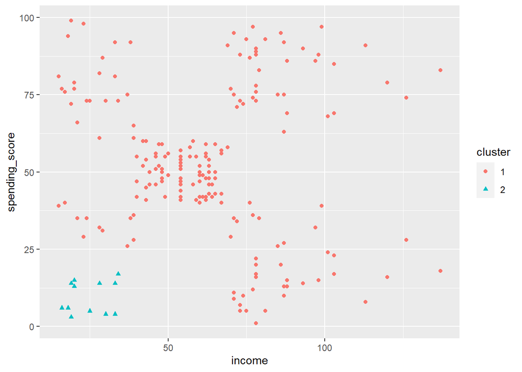

```r
lbls = cutree(fit, k = 2)
customer$cluster = as.factor(lbls)

ggplot(customer, aes(x = income, y = spending_score, color = cluster, shape = cluster)) +
  geom_point()
```

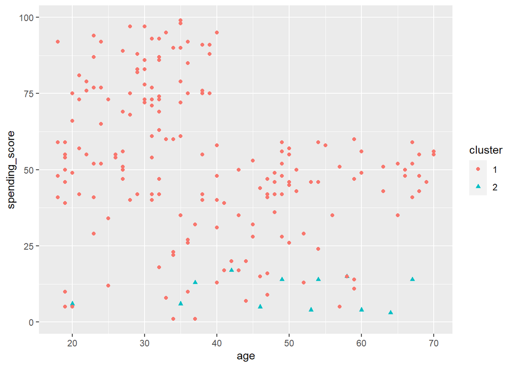

```r
ggplot(customer, aes(x = age, spending_score, color = cluster, shape = cluster)) +
  geom_point()
```

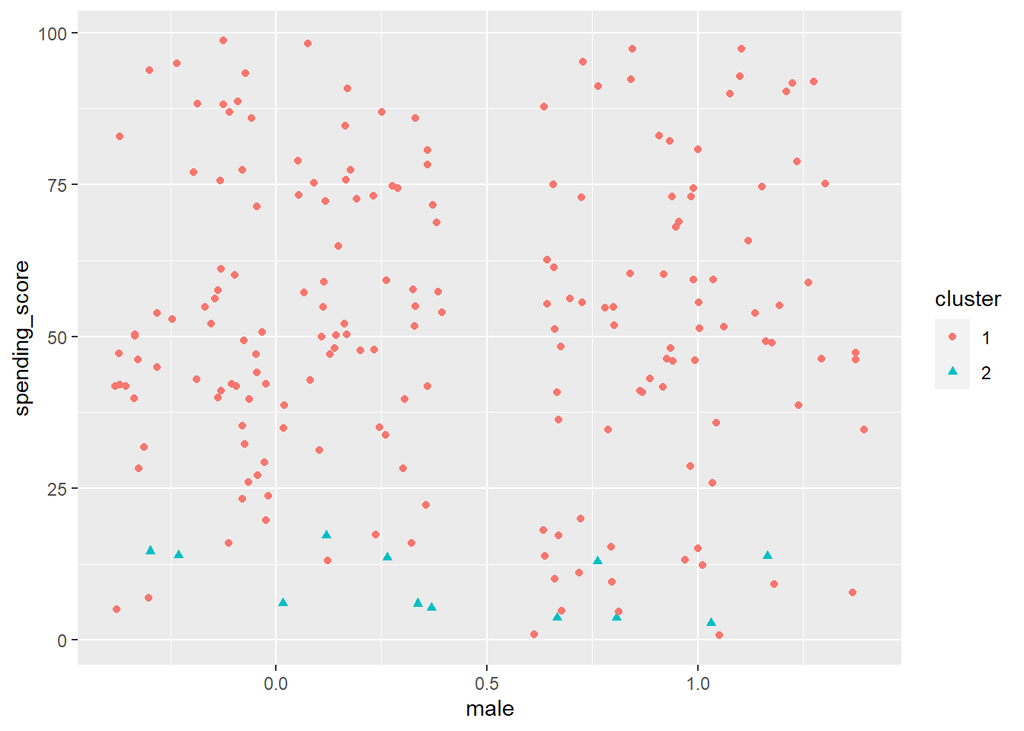

```r
ggplot(customer, aes(x = male, spending_score, color = cluster, shape = cluster)) +
  geom_jitter()
```

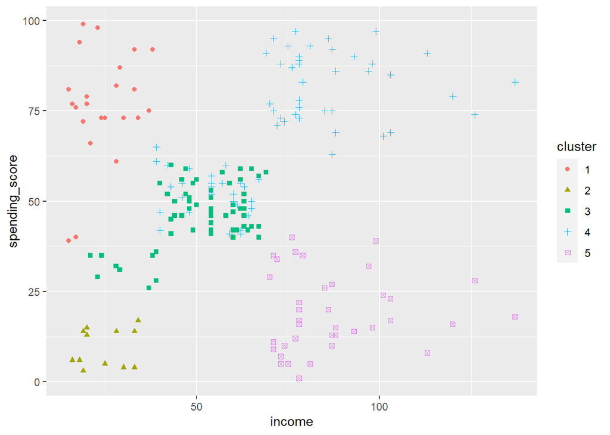

```r
lbls = cutree(fit, k = 5)
customer$cluster = as.factor(lbls)

ggplot(customer, aes(x = income, y = spending_score, color = cluster, shape = cluster)) +
  geom_point()
```

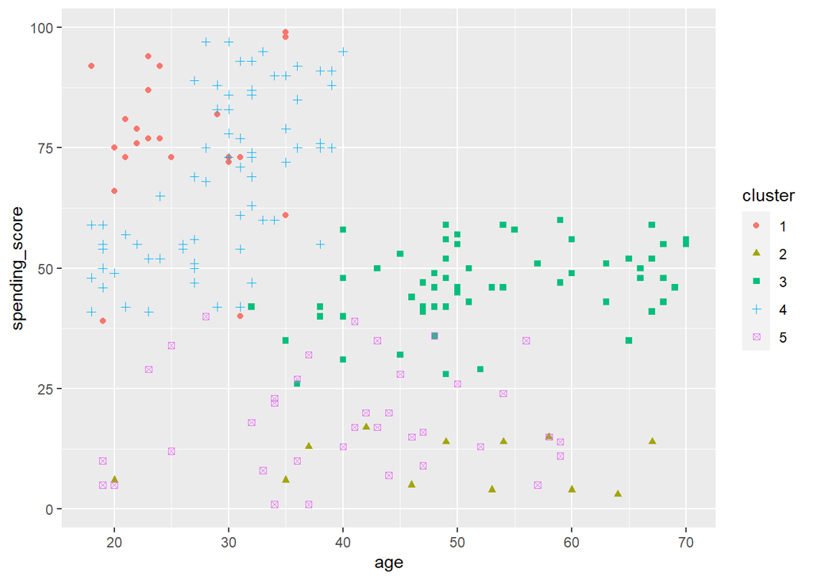

```r
ggplot(customer, aes(x = age, spending_score, color = cluster, shape = cluster)) +
  geom_point()
```

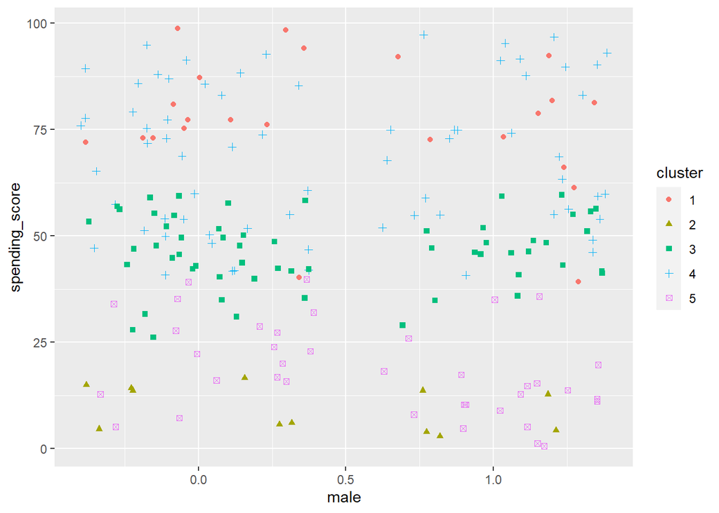

```r
ggplot(customer, aes(x = male, spending_score, color = cluster, shape = cluster)) +
  geom_jitter()
```